# Bike Trip Data Analysis

The goal of this project is to wrangle, analyze and visualize data.

- Introduction
- Part I - Gathering Data
- Part II - Accessing Data - Visual and Programatic
- Part III - Cleaning Data
- Part IV - Storing Data
- Part V - Analyzing and Visualizing Data

  ```
    - [Univariate Analysis]
    - [Bivariate Analysis]
    - [Multivariate Analysis]
  ```

- Part VI - Conclusion

# Introduction

The data set includes information about individual rides made between 2017 and 2019 in a bike-sharing system covering the greater San Francisco Bay area. The bike sharing system is provided by Bay Wheels under Lyft. Bay Wheels trip history data was downloaded from the below url:

https://s3.amazonaws.com/baywheels-data/index.html

Each trip data includes various details like

Trip Duration (seconds), Start Time and Date, End Time and Date, Start Station ID, Start Station Name, Start Station Latitude, Start Station Longitude, End Station ID, End Station Name, End Station Latitude, End Station Longitude, Bike ID, User Type (Subscriber or Customer – “Subscriber” = Member or “Customer” = Casual), member_birth_year, member_gender

We will perform various univariate,bi-variate and multivariate analysis on the data. Both fordgobike and baywheel data is used for the analysis

## Univariate Exploration

1. Average duration of trips

```python
df_bikedata['duration_min'] = df_bikedata['duration_sec']/60
```

```python
print(df_bikedata['duration_min'].max(), df_bikedata['duration_min'].min())
```

```
1439.4833333333333 1.0
```

```python
df_bikedata.duration_min.describe()
```

```
count    4.778909e+06
mean     1.425803e+01
std      3.821612e+01
min      1.000000e+00
25%      5.966667e+00
50%      9.450000e+00
75%      1.473333e+01
max      1.439483e+03
Name: duration_min, dtype: float64
```

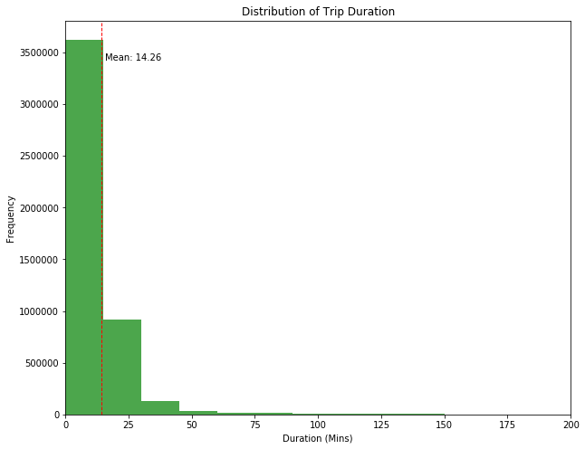

```python
plt.figure(figsize=[10,8])
rang = np.arange(0, df_bikedata['duration_min'].max() + 60, 15)
plt.hist(data = df_bikedata , x = 'duration_min' , bins = rang, color='green', alpha=0.7)
plt.xlim(0,200)
plt.axvline(df_bikedata.duration_min.mean(), color='r', linestyle='dashed', linewidth=1)
min_ylim, max_ylim = plt.ylim()
plt.text(df_bikedata.duration_min.mean()*1.1, max_ylim*0.9, 'Mean: {:.2f}'.format(df_bikedata.duration_min.mean()))
plt.title('Distribution of Trip Duration')
plt.xlabel('Duration (Mins)')
plt.ylabel('Frequency')
```

The histogram is clearly right skewed ad indicates that almost 75% of the data is less than mean duration of 14.26 mins. It can be deduced that most people rent bikes for short trips of less than 15 mins.

1. Which user type rents more bikes?

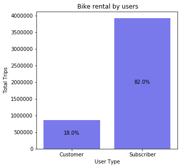

```python
# create the plot
plt.figure(figsize=[5,5])
sns.countplot(data = df_bikedata, x = 'user_type',  color = 'b', alpha=0.6)

# add annotations
n_points = df_bikedata.shape[0]
cat_counts = df_bikedata['user_type'].value_counts()
locs, labels = plt.xticks() # get the current tick locations and labels

# loop through each pair of locations and labels
for loc, label in zip(locs, labels):

    # get the text property for the label to get the correct count
    count = cat_counts[label.get_text()]
    pct_string = '{:0.1f}%'.format(100*count/n_points)

    # print the annotation in the middle of the bar
    plt.text(loc, count*0.5, pct_string, ha = 'center', color = 'k')

plt.title(' Bike rental by users')
plt.xlabel('User Type')
plt.ylabel('Total Trips')
```

Around 82% of the trips are used by Subscribers whereas only 18% is used by Customers.

1. When is the most number of trips made? (Day, Month and year)

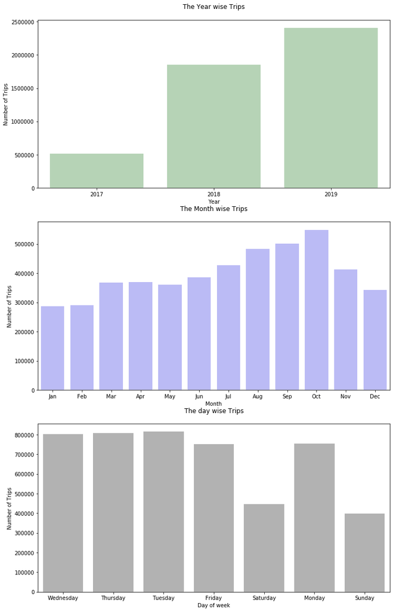

```python
plt.figure(figsize=[12,20])

plt.subplot(3,1, 1)
sns.countplot(data = df_bikedata, x = 'start_year', color = 'g', alpha = 0.3)
plt.title('The Year wise Trips\n')
plt.xlabel('Year')
plt.ylabel('Number of Trips')

plt.subplot(3,1, 2)
sns.countplot(data = df_bikedata, x = 'start_mon', color = 'b', alpha = 0.3)
plt.title('The Month wise Trips\n')
plt.xlabel('Month')
plt.ylabel('Number of Trips')

plt.subplot(3, 1, 3)
sns.countplot(data = df_bikedata, x = 'start_weekday', color = 'k', alpha = 0.3)
plt.title('The day wise Trips\n')
plt.xlabel('Day of week')
plt.ylabel('Number of Trips')
```

Most trips in were made during the months from August to October. The maximum trips where made in October. It can be noted that the trips are slightly less in the winter season. Trips taken high during weekdays (Mon - Fri) compared to Weekends. It can be justified by the fact that people commute less to work and study during weekends compared to weekdays.

## Bivariate Exploration

[output not shown]

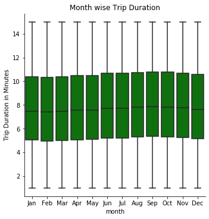

```python
plt.figure(figsize = [12,12])
sns.catplot(data = df_new,
            x = 'start_mon' , y = 'duration_min' , kind="box", color = 'g')
plt.title('Month wise Trip Duration')
plt.xlabel('month')
plt.ylabel('Trip Duration in Minutes')
```

There is no clear trend between the month of bike rental and trip duration. This could be because the weather change in San Francisco is not quite as distinct as in other regions of the country.

2.Does customer type effect the trip duration ?

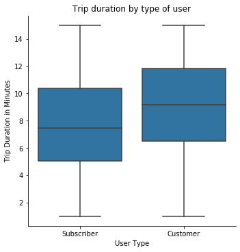

```python
base_color = sns.color_palette()[0]
sns.catplot(data = df_new, x = 'user_type', y = 'duration_min',color = base_color,kind='box')
plt.title('Trip duration by type of user');
plt.xlabel('User Type')
plt.ylabel('Trip Duration in Minutes')
```

Customers make trips of higher duration than subscribers.

## Multivariate Exploration

1. How does year,month and usertype effect bike rental?

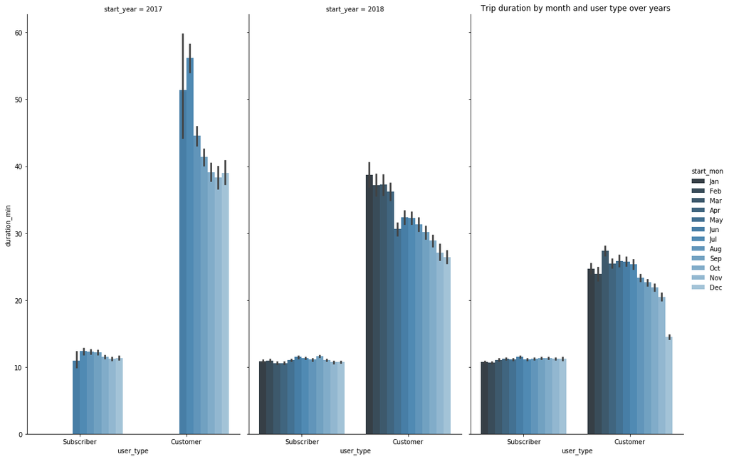

```python
sns.catplot(x="user_type", y="duration_min",
                hue="start_mon", col="start_year",
                data=df_bikedata, kind="bar",
                height=10, aspect=.5, palette="Blues_d");
plt.title('Trip duration by month and user type over years ');
```

1. How does gender and usertype effect trips made?

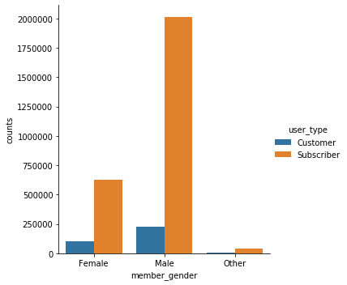

```python
sns.catplot(x="member_gender", y="counts", hue="user_type", kind="bar", data=df_ge_us);
```

Most trips are made by Male users, majority of which is made by Subscribers. Bike trips made by 'other' gender is very less compared to Male and Female users. For all three genders, subscribers make maximum number of trips.

1. Which gender and user type uses more bike_share_for_all_trip's ?

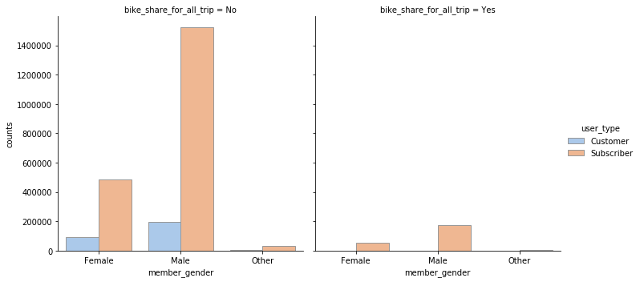

```python
sns.catplot(x="member_gender", y="counts", hue="user_type", col="bike_share_for_all_trip",kind="bar", data=df_s_e,palette="pastel", edgecolor=".6");
```

Most users don't use Bike Share for All program. The program is mostly used by Male users Subscribers. Customers don't use Bike Share for All program as Customers may not use bike rental multiple times.

### Interesting or surprising interactions between features!

- Even though most number of trips were made by Subscribers, their trip duration was less compared to Customers.
- Interestingly very less users make use of Bike Share for All program.

## Conclusion

1) 82% of the bike trips are made by Subscribers. 2) The average trip duration is around 15 mins. 3) Most trips are made during weekdays than weekends. 4) Usually Customers take longer trip_duration than Subscribers. 5) The trip duration of Customers has a decreasing trend from January to December, whereas the trip duration remains stable for Subscribers. 6) Male Subscribers made the most number of trip from 2017 to 2019. 7) Bike Share For All program is not very popular as there are only very few Subscribers who make use of the program.

### References:

```
https://seaborn.pydata.org/tutorial.html
https://matplotlib.org/3.2.1/gallery/lines_bars_and_markers/categorical_variables.html
https://stackoverflow.com/questions/20906474/import-multiple-csv-files-into-pandas-and-concatenate-into-one-dataframe
```